# Nestedness and robustness

```r
library(bipartite) # will also load vegan
library(ggplot2)
```

# 1. Nestedness

There are several methods for calculting the nestedness of a matrix. NODF is the most widely used metric and we will focus on it. NODF is evaluated separently per rows and columns, and then these scores are combined to get the NODF of the whole network. You are encouraged to look at the rationale behind it and how it compares to other metrics [1,2]. Nestedness has also been suggested for weighted networks [3,4], but we will work with binary networks.

Both `vegan` and `bipartite` have a function to calculate nestedness already implemented. The `vegan` package is more flexible. A basic example:

```r
data("memmott1999")
memmott1999_binary <- 1*(memmott1999>0)
nodf <- nestednodf(memmott1999_binary)
nodf
```

```
## N columns  : 42.53719
## N rows     : 45.97197
## NODF       : 42.84196
## Matrix fill: 0.1513924
```

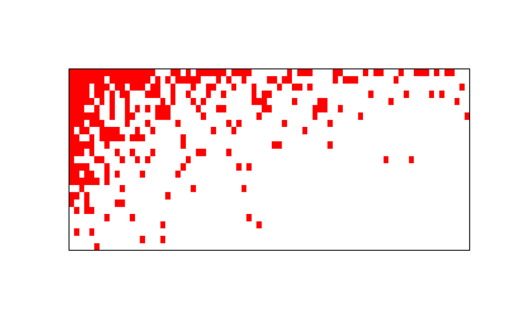

```r
plot(nodf)
```

Using `oecosimu` in `vegan`, calculting nestedness of a web and comparing it to a null model is super-easy! First we will compare to an equiprobabe shuffling algorithm:

```r
nodf_eval_1 <- oecosimu(memmott1999_binary, nestednodf, "r00", nsimul = 100)
nodf_eval_1$statistic # This is the NODF of the observed network
```

```
## N columns  : 42.53719
## N rows     : 45.97197
## NODF       : 42.84196
## Matrix fill: 0.1513924
```

```r
names(nodf_eval_1$oecosimu) # look at the ?oecosimu help for details on what are these values.
```

```
## [1] "z"           "means"       "pval"        "simulated"   "method"
## [6] "statistic"   "alternative" "isSeq"
```

```r
nodf_eval_1 # The networks is significantly nested.
```

```
## oecosimu object
##
## Call: oecosimu(comm = memmott1999_binary, nestfun = nestednodf,
## method = "r00", nsimul = 100)
##
## nullmodel method 'r00' with 100 simulations
##
## alternative hypothesis: statistic is less or greater than simulated values
##
## N columns  : 42.53719
## N rows     : 45.97197
## NODF       : 42.84196
## Matrix fill: 0.1513924
##
##           statistic    SES   mean   2.5%    50%  97.5% Pr(sim.)
## N.columns    42.537 34.098 16.468 14.720 16.541 17.759 0.009901 **
## N.rows       45.972 36.730 16.179 14.600 16.150 17.750 0.009901 **
## NODF         42.842 35.597 16.443 14.815 16.521 17.708 0.009901 **
## ---
## Signif. codes:  0 '***' 0.001 '**' 0.01 '*' 0.05 '.' 0.1 ' ' 1
```

> 1. Try comparing to a fixed shuffling algorithm like `curveball`. Are there differences in the results when using different null models? Why?
> 2. Nestedness has been shown to be correlated with network density and the number of species. That renders comparisons of nestedness scores across many networks statistically inappropriate. How can we compare values of nestedness across networks?

# 2. Network robustness

The question of how networks with different stuctures respond to failure of (or attack on) nodes has been fundamental in the broader network science. For example, attack on hub vs random nodes will result in fundamentally different failure dynamics. These concepts are naturally adapted in ecology. In our next exercise we will try to build an algorithm for simulating species extinctions in food webs. Yet to give you a sense of how such analysis can look like, let’s first take a look at existing implementation in `R` for bipartite networks. In the following implemetation we simulate an extinction process of the plants. There are 3 possible scenarios to extinction [5]:

1. Least connected –> most connected
2. Most connected –> leaset connected
3. Random

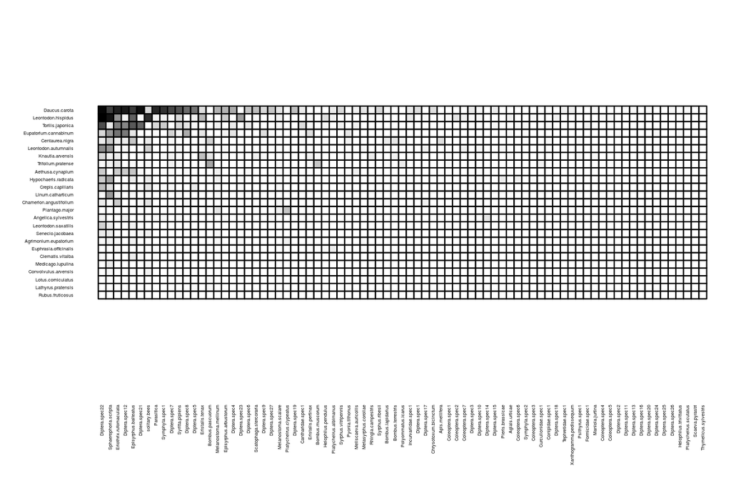

```r
data("memmott1999")
visweb(memmott1999)
```

```r
# Follow secondary extinction of pollinators, while removing plants.
ex_random <- second.extinct(memmott1999, method = 'random', participant = 'lower', nrep=100, details=F) # Replicate simulations because it is random.
ex_random[1:3,]
```

```
##      no ext.lower ext.higher
## [1,]  1         1       0.57
## [2,]  2         1       1.14
## [3,]  3         1       1.01
```

```r
ex_least <- second.extinct(memmott1999, method = 'abundance', participant = 'lower', details=F)
ex_least[1:3,]
```

```
##      no ext.lower ext.higher
## [1,]  1         1          0
## [2,]  2         1          0
## [3,]  3         1          0
```

```r
ex_most <- second.extinct(memmott1999, method = 'degree', participant = 'lower', details=F)
ex_most[1:3,]
```

```
##      no ext.lower ext.higher
## [1,]  1         1         10
## [2,]  2         1          6
## [3,]  3         1          3
```

We can then plot an *Attack Tolerance Curve* [5]. Pardon for the ugly plots, these are built-in and very difficult to tweak directly. The function returns the exponent $a$ of $y \sim 1 - x^a$. So ‘’$a$ is a measure of extinction vulnerability. The more gradual the secondary extinctions, the lower the absolute value of $a$. Or, phrased differently, large absolute values of $a$ indicate a very abrupt die-off, indicative of high initial redundancy in the network.’’ (from `?slope.bipartite`).

```r
par(mfrow=c(2,2))
slope.bipartite(ex_random, cex.axis=0.1) #fit a curve to the extinction data
```

```
## exponent
##  2.52404
```

```r
slope.bipartite(ex_least) #fit a curve to the extinction data
```

```
## exponent
## 15.21714
```

```
##  exponent
## 0.5751362
```

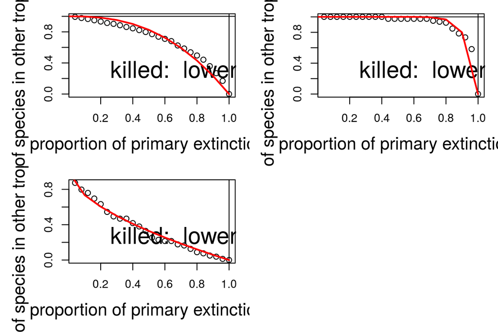

```r
slope.bipartite(ex_most) #fit a curve to the extinction data
```

The area under the curve can be used to quantify “robustness”, as suggested by Burgos [6].

```r
# Robustness
robustness(ex_random)
```

```
## [1] 0.7100615
```

```r
robustness(ex_least)
```

```
## [1] 0.9263332
```

```r
robustness(ex_most)
```

```
## [1] 0.3605161
```

> 3. What can you say about the tolerance of the network to different extinction regimes? Repeat that exercise, now removing pollinators. Is the tolerance of the network different?

> **Advanced exercise (better go back to this once we know how to generate networks):** To understand how robustness is affected by network properties, generate an ensemble of networks of different topologies (e.g., size and density), and test their robustness. Can you find any associations between topology and robustness? Specifically, try to test the relationship between nestedness and robustness. Are more nested networks more robust? under which regime of extinction?

## 2.1 Programming an algorithm for extinction cascades

Now we can try doing that by ourselves. **We do not need to do that as fancy as the `second.extinct` function!** What is the basic logic of the algorithm?

# 3. References

1. Almeida-Neto M, Guimarães PR, Loyola RD, Ulrich W. A consistent metric for nestedness analysis in ecological systems: reconciling concept and measurement. Oikos. 2008;117: 1227–1239.
2. Ulrich W, Almeida-Neto M, Gotelli NJ. A consumer’s guide to nestedness analysis. Oikos. 2009;118: 3–17.
3. Almeida-Neto M, Ulrich W. A straightforward computational approach for measuring nestedness using quantitative matrices. Environmental Modelling & Software. 2011;26: 173–178.
4. Staniczenko PPA, Kopp JC, Allesina S. The ghost of nestedness in ecological networks. Nat Commun. 2013;4: 1391.
5. Memmott J, Waser NM, Price MV. Tolerance of pollination networks to species extinctions. Proc R Soc B. 2004;271: 2605–2611.
6. Burgos E, Ceva H, Perazzo RPJ, Devoto M, Medan D, Zimmermann M, et al. Why nestedness in mutualistic networks? J Theor Biol. 2007;249: 307–313.